# 1D simulated case study: Diagnosis of the HSGP approximation

2022-01-12.

## Load packages

```r
library(rstan)
library(cmdstanr)
options(mc.cores = parallel::detectCores())
rstan_options(auto_write = FALSE)
library(posterior)
library(bayesplot)
library(mgcv)
library(brms)
library(RColorBrewer)
library(ggplot2)
library(loo)
library(latex2exp)
library(gridExtra)
library(reshape2)
library(plyr)
```

## Synthetic dataset

A synthetic dataset $\boldsymbol{y}$ with a true data generating function $f(x)$ which is a Gaussian process (GP) with a Matern-$\nu$=3/2 kernel. Errors $\boldsymbol{\epsilon}$ with noise $\sigma$ are added to $f(x)$ to form the final synthetic noisy dataset $\boldsymbol{y}$.

$$\begin{align*}
\begin{split}
\boldsymbol{y} &= \boldsymbol{f} + \boldsymbol{\epsilon} \\
\boldsymbol{\epsilon} &\sim \text{Normal}(\boldsymbol{0}, \sigma^2 \boldsymbol{I}) \\
f(x) &\sim \text{GP}(0, k(x, x', \theta)),
\end{split}
\end{align*}$$

where $k(x, x', \theta)$ is a Matern-$\nu$=3/2 kernel as a function of input values $x$ and parameters $\theta$ (marginal variance of the GP and lengthscale of the kernel)

### Draw the true data generative function $f(x)$ from a GP

#### Input predictive space

Vector of predictive input points `x_pred`, length of `x_pred` (`N_pred`) and vector of indices of `x_pred` (`vv_pred`).

```r
x_pred <- seq(-1,1,0.002)
N_pred <- length(x_pred)
vv_pred <- 1:length(x_pred)
```

Half range of the input domain

```r
S <- abs((max(x_pred) - min(x_pred))/2)
S
```

```
[1] 1
```

#### Draw $f(x)$ using Stan

`param_v` identifies the order $\nu$ of the kernel

```r
param_v <- 3
```

Marginal variance `gpscale` and lengthscale `lscale`

```r
gpscale <- 1
lscale <- 0.2
```

Random variable `eta` to simulate from the GP

```r
seed <- 88646
set.seed(seed)
eta <- rnorm(N_pred, 0, 1)
```

Data to be passed to Stan

```r
standata <- list(x= x_pred,
                  N= N_pred,
                  param_v= param_v,
                  gpscale= gpscale,
                  lscale= lscale,
                  eta= eta)
```

Compiling the simulating model

```r
simuGP_mod <- cmdstanr::cmdstan_model(stan_file = "stancode_SIMU.stan")
```

Model sampling

```r
fit_SIMU <- simuGP_mod$sample(data= standata,
                                iter_warmup=100,
                                iter_sampling=100,
                                chains=1, thin=1, init=0.5,
                                fixed_param=TRUE)
fit_SIMU <- read_stan_csv(fit_SIMU$output_files())
```

Drawn $f(x)$

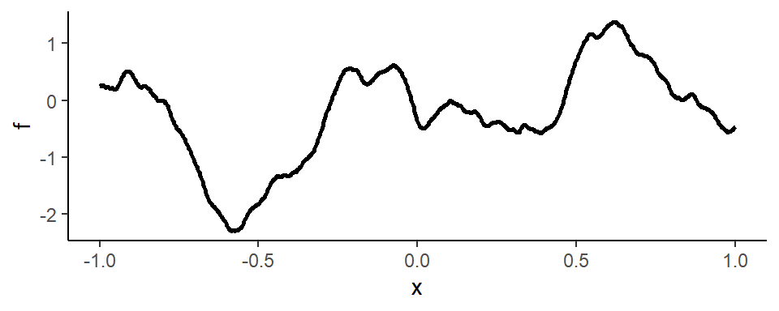

### Adding noise to $f(x)$

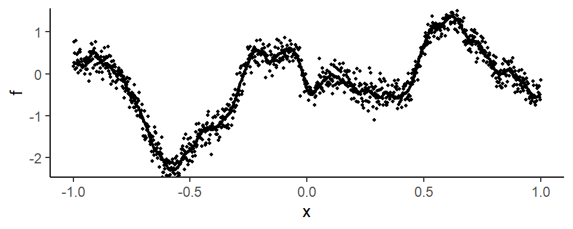

```r
seed <- 6734
set.seed(seed)

sd <- 0.2
y <- list()
y <- f_true + rnorm(N_pred, 0, sd)

ggplot(data.frame(f=f_true, x=x_pred), aes(x=x, y=f))  +
    geom_line(color = 'black', size=1) +
    geom_point(y= y, size=0.7, color='black') +
    theme_classic()
```

## Modeling data

A random sample `x_sample` (n=250) from the input predicting points `x_pred`

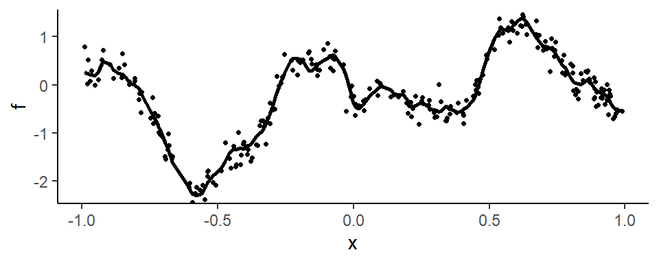

```r
seed <- 6734
set.seed(seed)
vv_sample <- sort(sample(vv_pred, 250))
x_sample <- x_pred[vv_sample]
N_sample <- length(x_sample)

ggplot(data.frame(f=f_true[vv_sample], x=x_sample), aes(x=x, y=f))  +
    geom_line(color = 'black', size=1) +
    geom_point(y= y[vv_sample], size=0.9, color='black') +
    theme_classic()
```

### Interpolating data

Select samples from `x_sample` for interpolation

```r
seed <- 6734
set.seed(seed)
vv_inter <- vv_sample[which((x_sample>(-0.50)&x_sample<(-0.35))|(x_sample>(0.13)&x_sample<0.30))]
N_inter <- length(vv_inter)
x_inter <- x_pred[vv_inter]
```

### Extrapolating data

Select samples from `x_sample` for extrapolation

```r
vv_extra <- vv_sample[which(x_sample<(-0.8)|x_sample>0.82)]
N_extra <- length(vv_extra)
x_extra <- x_pred[vv_extra]
```

### Training data

Select samples from `x_sample` for training

```r
vv_train <- setdiff(vv_sample, c(vv_extra, vv_inter))
N_train <- length(vv_train)
x_train <- x_pred[vv_train]
```

### Plot of training (black), interpolation (red) and extrapolation (red) points

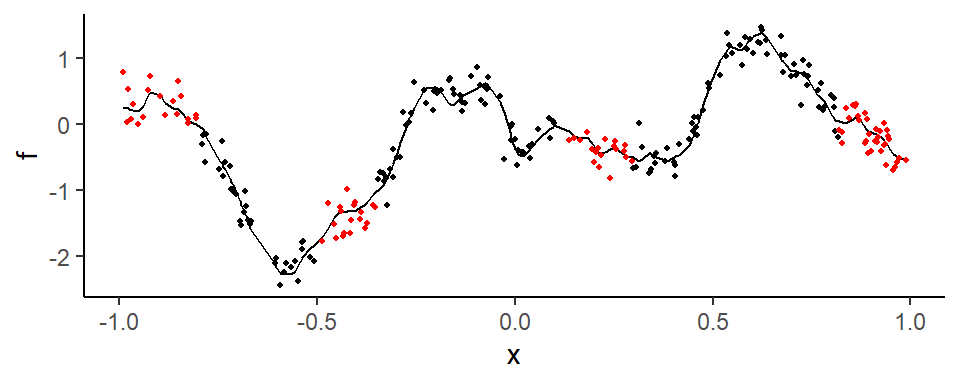

## GP model fitting

Initialization of programming objects

```r
fit_GP <- list()
```

### Data

Data to Stan

```r
standata_GP <- list(x_pred= x_pred,
                     y= y,
                     vv_train= vv_train,
                     N_pred= N_pred,
                     N_train= N_train,
                     param_v= param_v,
                     f_true= f_true)
```

### Model fitting

Compilation of the exact GP model

```r
GP_mod <- cmdstanr::cmdstan_model(stan_file = "stancode_GP.stan")
```

Model fitting

```r
load("fit_GP.rData")
```

```r
# fit_GP <- GP_mod$sample(data= standata_GP,
#                           iter_warmup=50,
#                           iter_sampling=50,
#                           chains=4, thin=1, init=0.5)
# fit_GP <- read_stan_csv(fit_GP$output_files())
```

Summaries of variable estimates

```
             mean     se_mean         sd      2.5%       50%     97.5%
lscale  0.2187425 0.004971630 0.05203359 0.1365156 0.2128135 0.3223322
gpscale 1.0364395 0.016120815 0.22515098 0.6867622 1.0185500 1.5069023
sigma   0.1931322 0.001583207 0.01229205 0.1722674 0.1920935 0.2231560
            n_eff      Rhat
lscale  109.53931 0.9995803
gpscale 195.06246 0.9914350
sigma    60.28005 1.0514826
```

Simulation chains for the variables after warmup

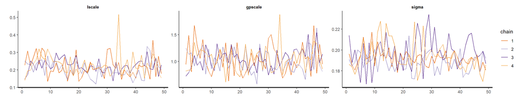

### Posterior predictive distributions

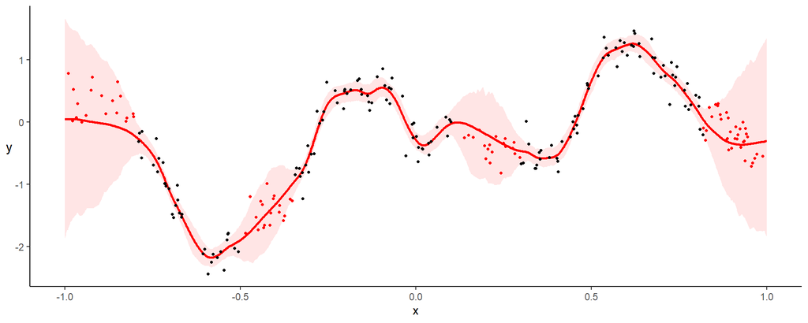

## Diagnosis

### Relationships among $m$, $l$ and $c$

Relationship among the number of basis functions $m$, the lengthscale $l$ and the boundary factor $c$ for a **Matern-$\nu=3/2$ kernel**:

$$m= 3.32 \frac{c}{\left(\frac{l}{S}\right)^{1.08}} \;\; \Leftrightarrow \;\; \frac{l}{S}= 3.04 \, \frac{c^{0.926}}{m^{0.926}}$$

```r
m_MAT32 <- function(c,l,S){ ceiling(3.32 * c / (l/S)^1.08) }

l_MAT32 <- function(c,m,S){ round(S * 3.04 * c^0.926 / m^0.926, 3) }
```

with
$$c \, \geq \, 0.98 + 2.01 \, \frac{l}{S}$$

as a function of $l$ and $S$, where $S$ is the half range of the input domain,

```r
c_vs_l_MAT32 <- function(l,S){
  if(0.98+2.01*l/S < 1.25){
    c = 1.3
  }else{
    if(0.98+2.01*l/S >= 1.25 & 0.98+2.01*l/S < 1.45){
      c = 1.5
    }else{
      if(0.98+2.01*l/S >= 1.45 & 0.98+2.01*l/S < 1.95){
        c = 2
      }else{
        if(0.98+2.01*l/S >= 1.95 & 0.98+2.01*l/S < 2.45){
          c = 2.5
        }else{
          if(0.98+2.01*l/S >= 2.45 & 0.98+2.01*l/S < 2.95){
            c = 3
          }else{
            c = ceiling(0.98+2.01*l/S)
          } } } } }
  c
}
```

or, equivalently,
$$c \, \geq \, 31868.07 \, m^{-0.172 \, log(m)^2 \, + \, 1.963 \, log(m) \, - \, 7.634}$$

as a function of $m$.

```r
c_vs_m_MAT32 <- function(m){
  if(31868.07*m^(-0.1722*log(m)^2+1.9633*log(m)-7.6338) < 1.25){
    c = 1.3
  }else{
    if(31868.07*m^(-0.1722*log(m)^2+1.9633*log(m)-7.6338) >= 1.25 & 31868.07*m^(-0.1722*log(m)^2+1.9633*log(m)-7.6338) < 1.45){
      c = 1.5
    }else{
      if(31868.07*m^(-0.1722*log(m)^2+1.9633*log(m)-7.6338) >= 1.45 & 31868.07*m^(-0.1722*log(m)^2+1.9633*log(m)-7.6338) < 1.95){
        c = 2
      }else{
        if(31868.07*m^(-0.1722*log(m)^2+1.9633*log(m)-7.6338) >= 1.95 & 31868.07*m^(-0.1722*log(m)^2+1.9633*log(m)-7.6338) < 2.45){
          c = 2.5
        }else{
          if(31868.07*m^(-0.1722*log(m)^2+1.9633*log(m)-7.6338) >= 2.45 & 31868.07*m^(-0.1722*log(m)^2+1.9633*log(m)-7.6338) < 2.95){
            c = 3
          }else{
            c = ceiling(31868.07*m^(-0.1722*log(m)^2+1.9633*log(m)-7.6338))
          } } } } }
  c
}
```

### User-guide for diagnosis

**Assumption of the diagnosis tool:**

- Under inaccurate HSGP approximation, the estimated lengthscale $\hat{l}$ is (always) smaller than the true lengthscale $l$.

**User-guide with the steps to perform diagnosis:**

0. Make a first guess of the lengthscale $l_1$ of the function to be learned.

*Iteration 1*

1. Obtain the minimum valid boundary factor $c_1$ determined by $l_1$ using the functional relationship $c_1 \geq \, 0.98 + 2.01 \, \frac{l_1}{S}$, where $S$ is the half range of the input domain.
2. Obtain the mimimum valid number of basis functions $m_1$ determined by $l_1$ and $c_1$ using the functional relationship $m_1= 3.32 \, \frac{c_1}{\left(\frac{l_1}{S}\right)^{1.08}}$. Notice that $l_1$ can also be read as the minimum lengthscale that can be accurately fitted determined by $m_1$ and $c_1$ $\left(\frac{l_1}{S}= 3.04 \, \frac{(c_1)^{0.926}}{(m_1)^{0.926}}\right)$.
3. Fit the HSGP model and assess residuals: check any residual trends, compute *rmse* (Root mean square error), $R^2$ (Coefficient of variation) and *elpd* (Expected log predicitve density).
4. Check the diagnostic of whether $\, \hat{l_1} \geq l_1$.

   4.1. If the diagnostic is TRUE, the HSGP model approximation must be sufficiently accurate or, at least, very close to be sufficiently accurate. Then user can continue with step 5.

   4.2. If the diagnostic is FALSE, the HSGP model approximation can not be sufficiently accurate. Then user must move to step 10.

*Iteration 2*

*(If the diagnostic in step 4 is TRUE)*

5. Set $\, m_2 = m_1 + 10$.
6. Obtain the minimum valid boundary factor $c_2$ determined by the estimated $\hat{l_1}$ using the functional relationship $c_2 \, \geq \, 0.98 + 2.01 \, \frac{\hat{l_1}}{S}$, where $S$ is the half range of the input domain.
7. Obtain the mimimum lengthscale $l_2$ that can be accurately fitted determined by $m_2$ and $c_2$ using the functional relationship $\frac{l_2}{S}= 3.04 \, \frac{(c_2)^{0.926}}{(m_2)^{0.926}}$.
8. Fit the HSGP model and

   8.1. Check whether $\, \hat{l_2} \geq \hat{l_1}$

   8.2. Check stability in *rmse*, $R^2$ and *elpd* from previous iteration
9. If the two verifications above are TRUE, the HSGP model approximation must be sufficiently accurate, and diagnosis ends here. Otherwise, repeat steps 5-9 and update parameters.

*(If the diagnostic in step 4 is FALSE)*

10. Set $\, l_2 = \hat{l_1}$.
11. Repeat steps 1-4 and update parameters.

### Iteration 1

Initializing programming objects:

```r
standata <- list()
fit_diagnosis <- list()
l <- vector()
c <- vector()
m <- vector()
l_hat <- vector()
residual <- list()
evaluation <- list()
diagnosis <- list()
rmse <- vector()
eR2 <- vector()
elpd <- vector()
```

Iteration index

```r
i <- 1
```

#### Setting $m$, $l$ and $c$

1. Making the first guess that the lengthscale $l_1$ might be 0.5

```r
l[i] <- 0.5
l[i]
```

```
[1] 0.5
```

2. The boundary factor $c_1$ has to fulfill $c_1 \, \geq \,0.98 + 2.01 \, \frac{l_1}{S}$

```r
c[i] <- c_vs_l_MAT32(l=l[i], S=S)
c[i]
```

```
[1] 2.5
```

3. The number of basis functions $m_1$ as a function of $l_1$ and $c_1$: $\; m_1 = 3.32 \, \frac{c_1}{(l_1/S)^{1.08}}$

```r
m[i] <- m_MAT32(c=c[i], l=l[i], S=S)
m[i]
```

```
[1] 18
```

#### Data to Stan

```r
standata[[i]] <- list(y= y,
                       f_true= f_true,
                       x_pred= x_pred,
                       vv_train= vv_train,
                       N_pred= N_pred,
                       N_train= N_train,
                       param_v= param_v,
                       c= c[i],
                       L= c[i]*S,
                       M= m[i])
str(standata[[i]])
```

```
List of 10
 $ y       : Named num [1:1001] 0.185 0.762 0.266 0.492 0.108 ...
  ..- attr(*, "names")= chr [1:1001] "f[1]" "f[2]" "f[3]" "f[4]" ...
 $ f_true  : Named num [1:1001] 0.252 0.256 0.262 0.267 0.266 ...
  ..- attr(*, "names")= chr [1:1001] "f[1]" "f[2]" "f[3]" "f[4]" ...
 $ x_pred  : num [1:1001] -1 -0.998 -0.996 -0.994 -0.992 -0.99 -0.988 -0.986 -0.984 -0.982 ...
 $ vv_train: int [1:158] 106 107 110 111 127 131 133 135 141 143 ...
 $ N_pred  : int 1001
 $ N_train : int 158
 $ param_v : num 3
 $ c       : num 2.5
 $ L       : num 2.5
 $ M       : num 18
```

#### Model fitting

Compiling the HSGP model

```r
hsgp_mod <- cmdstanr::cmdstan_model(stan_file = "stancode_HSGP.stan")
```

Model fitting

```r
fit_diagnosis[[i]] <- hsgp_mod$sample(data= standata[[i]],
                                iter_warmup=1000,
                                iter_sampling=1000,
                                chains=4, thin=10, init=0.5)
fit_diagnosis[[i]] <- rstan::read_stan_csv(fit_diagnosis[[i]]$output_files())
```

Summaries of variable estimates

```
             mean      se_mean         sd       2.5%       50%     97.5%
lscale  0.1315103 0.0026522028 0.05641309 0.04457641 0.1295395 0.2632499
gpscale 1.3560022 0.0153806973 0.29748812 0.91078488 1.3216900 2.0750605
noise   0.2666813 0.0007515811 0.01451143 0.24215533 0.2652210 0.2986633
           n_eff      Rhat
lscale  452.4246 0.9993868
gpscale 374.0996 1.0035136
noise   372.7940 0.9984424
```

Simulation chains for the variables after warmup

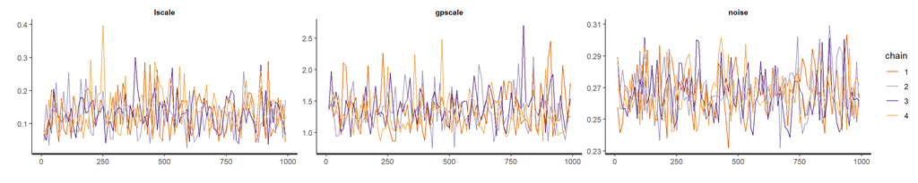

Plot of the posterior distributions

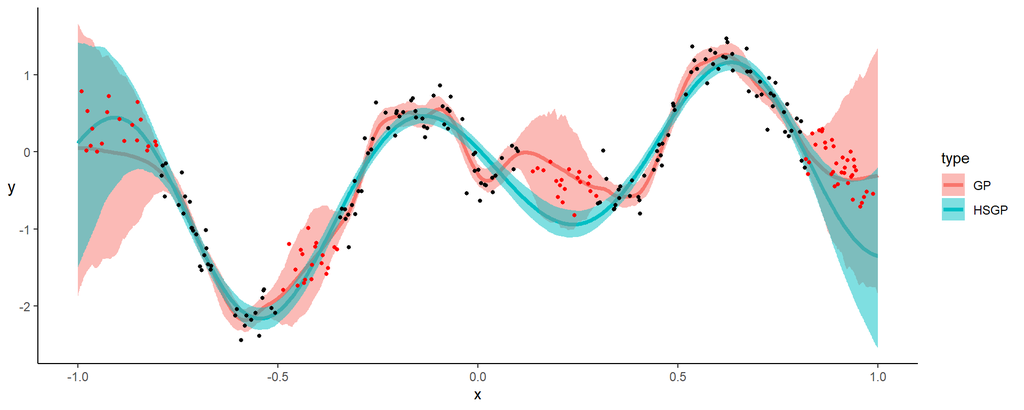

#### Model evaluation

Residuals `residual`, Bayesian $R^2$ (Coefficient of determination), and Log predictive density `lpd`

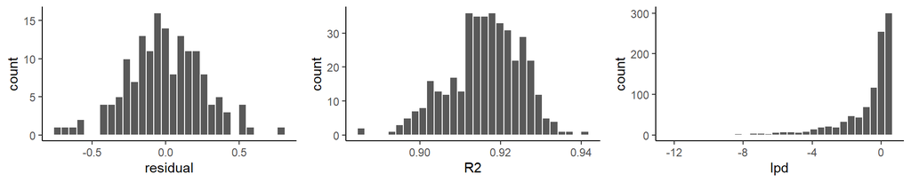

Root mean square error `rmse`, Bayesian $R^2$ (Coefficient of determination), and expected log predictive density `elpd`

| iter | rsme | R2 | elpd |
| --- | --- | --- | --- |
| 1 | 0.257 | 0.917 | -0.112 |

#### Diagnosis

1. Estimated lengthscale $\hat{l_1}$

```r
l_hat[i] <- round(summary(fit_diagnosis[[i]], pars = "lscale")$summary[,1], 3)
l_hat[i]
```

```
[1] 0.132
```

2. Check the diagnostic of whether $\, \hat{l_1} \geq l_1$

```r
l_hat[i] >= l[i]
```

```
[1] FALSE
```

**Summary table**

| iter | GP_func | l | c | m | l_hat | l_hat > l | rmse | R2 | elpd |
| --- | --- | --- | --- | --- | --- | --- | --- | --- | --- |
| 1 | f | 0.5 | 2.5 | 18 | 0.132 | FALSE | 0.257 | 0.917 | -0.112 |

### Iteration 2

Iteration index

```r
i <- 2
```

#### Setting $m$, $l$ and $c$

1. If the diagnostic $\hat{l_1} \geq l_1$ is FALSE:

   1.1. Update $l_2 = \hat{l_1}$

```r
if(l_hat[i-1] >= l[i-1]){
  print("Diagnoistic is TRUE")
}else{
  l[i] <- l_hat[i-1]
  l[i]
}
```

```
[1] 0.132
```

1.2. The boundary factor $c_2$ has to fulfill $c_2 \, \geq \, 0.98 + 2.01 \, \frac{l_2}{S}$

```r
if(l_hat[i-1] >= l[i-1]){
  print("Diagnoistic is TRUE")
}else{
  c[i] <- c_vs_l_MAT32(l=l[i], S=S)
  c[i]
}
```

```
[1] 1.3
```

1.3. The number of basis functions $m_2$ as a function of $l_2$ and $c_2$: $\; m_2= 3.32 \, \frac{c_2}{(l_2/S)^{1.08}}$

```r
if(l_hat[i-1] >= l[i-1]){
  print("Diagnoistic is TRUE")
}else{
  m[i] <- m_MAT32(c=c[i], l=l[i], S=S)
  m[i]
}
```

```
[1] 39
```

2. If the diagnostic $\hat{l_1} \geq l_1$ is TRUE:

   2.1. Update $m_2 = m_1 + 10$

```r
if(l_hat[i-1] >= l[i-1]){
  m[i] <- m[i-1] + 10
  m[i]
}else{
  print("Diagnoistic is FALSE")
}
```

```
[1] "Diagnoistic is FALSE"
```

2.2. The boundary factor $c_2$ has to fulfill $c_2 \, \geq \, 31868.07 \, (m_2)^{-0.172 \, log(m_2)^2 \, + \, 1.963 \, log(m_2) \, - \, 7.634}$

```r
if(l_hat[i-1] >= l[i-1]){
  c[i] <- c_vs_m_MAT32(m=m[i])
  c[i]
}else{
  print("Diagnoistic is FALSE")
}
```

```
[1] "Diagnoistic is FALSE"
```

2.3. The minimum valid lengthscale $l_2$ determined by $m_2$ and $c_2$: $\; l_2= S \cdot 3.04 \, \frac{(c_2)^{0.926}}{(m_2)^{0.926}}$

```r
if(l_hat[i-1] >= l[i-1]){
  l[i] <- l_MAT32(c=c[i], m=m[i], S=S)
  l[i]
}else{
  print("Diagnoistic is FALSE")
}
```

```
[1] "Diagnoistic is FALSE"
```

#### Data to Stan

```r
standata[[i]] <- list(y= y,
                       f_true= f_true,
                       x_pred= x_pred,
                       vv_train= vv_train,
                       N_pred= N_pred,
                       N_train= N_train,
                       param_v= param_v,
                       c= c[i],
                       L= c[i]*S,
                       M= m[i])
str(standata[[i]])
```

```
List of 10
 $ y       : Named num [1:1001] 0.185 0.762 0.266 0.492 0.108 ...
  ..- attr(*, "names")= chr [1:1001] "f[1]" "f[2]" "f[3]" "f[4]" ...
 $ f_true  : Named num [1:1001] 0.252 0.256 0.262 0.267 0.266 ...
  ..- attr(*, "names")= chr [1:1001] "f[1]" "f[2]" "f[3]" "f[4]" ...
 $ x_pred  : num [1:1001] -1 -0.998 -0.996 -0.994 -0.992 -0.99 -0.988 -0.986 -0.984 -0.982 ...
 $ vv_train: int [1:158] 106 107 110 111 127 131 133 135 141 143 ...
 $ N_pred  : int 1001
 $ N_train : int 158
 $ param_v : num 3
 $ c       : num 1.3
 $ L       : num 1.3
 $ M       : num 39
```

#### Model fitting

Compiling the HSGP model

```r
hsgp_mod <- cmdstanr::cmdstan_model(stan_file = "stancode_HSGP.stan")
```

Model fitting

```r
fit_diagnosis[[i]] <- hsgp_mod$sample(data= standata[[i]],
                                iter_warmup=1000,
                                iter_sampling=1000,
                                chains=4, thin=10, init=0.5)
fit_diagnosis[[i]] <- rstan::read_stan_csv(fit_diagnosis[[i]]$output_files())
```

Summaries of variable estimates

```
             mean      se_mean         sd      2.5%       50%     97.5%
lscale  0.2167139 0.0027852014 0.05360777 0.1327199 0.2111305 0.3423921
gpscale 1.0581523 0.0132905971 0.26786100 0.6739362 1.0024550 1.7597260
noise   0.1968196 0.0006635034 0.01249817 0.1742260 0.1961105 0.2241669
           n_eff      Rhat
lscale  370.4608 0.9988044
gpscale 406.1907 0.9960786
noise   354.8190 0.9948162
```

Simulation chains for the variables after warmup

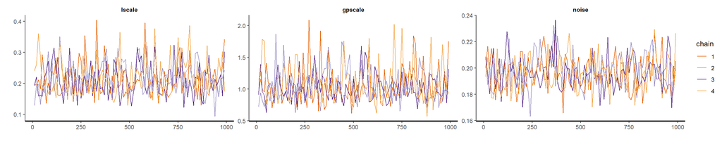

Plot of the posterior distributions

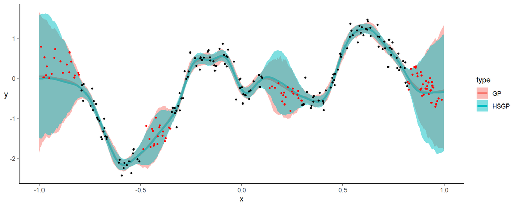

#### Model evaluation

Residuals `residual`, Bayesian $R^2$ (Coefficient of determination), and Log predictive density `lpd`

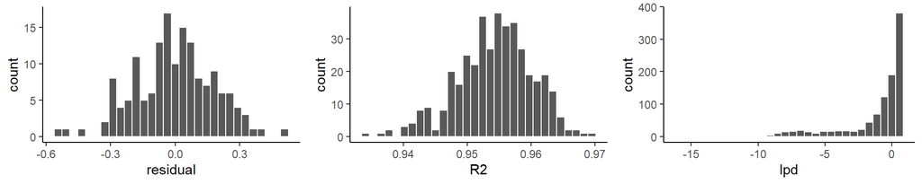

Root mean square error `rmse`, Bayesian $R^2$ (Coefficient of determination), and expected log predictive density `elpd`

| iter | rsme | R2 | elpd |
| --- | --- | --- | --- |
| 1 | 0.257 | 0.917 | -0.112 |
| 2 | 0.182 | 0.955 | -0.013 |

#### Diagnosis

1. Estimated lengthscale $\hat{l_2}$

```r
l_hat[i] <- round(summary(fit_diagnosis[[i]], pars = "lscale")$summary[,1], 3)
l_hat[i]
```

```
[1] 0.217
```

2. Check the diagnostic of whether $\, \hat{l_2} \geq l_2$

```r
l_hat[i] >= l[i]
```

```
[1] TRUE
```

**Summary table**

| iter | GP_func | l | c | m | l_hat | l_hat > l | rmse | R2 | elpd |
| --- | --- | --- | --- | --- | --- | --- | --- | --- | --- |
| 1 | f | 0.500 | 2.5 | 18 | 0.132 | FALSE | 0.257 | 0.917 | -0.112 |
| 2 | f | 0.132 | 1.3 | 39 | 0.217 | TRUE | 0.182 | 0.955 | -0.013 |

### Iteration 3

Iteration index

```r
i <- 3
```

#### Setting $m$, $l$ and $c$

1. If the diagnostic $\hat{l_2} \geq l_2$ is FALSE:

   1.1. Update $l_3 = \hat{l_2}$

```r
if(l_hat[i-1] >= l[i-1]){
  print("Diagnoistic is TRUE")
}else{
  l[i] <- l_hat[i-1]
  l[i]
}
```

```
[1] "Diagnoistic is TRUE"
```

1.2. The boundary factor $c_3$ has to fulfill $c_3 \, \geq \, 0.98 + 2.01 \, \frac{l_3}{S}$

```r
if(l_hat[i-1] >= l[i-1]){
  print("Diagnoistic is TRUE")
}else{
  c[i] <- c_vs_l_MAT32(l=l[i], S=S)
  c[i]
}
```

```
[1] "Diagnoistic is TRUE"
```

1.3. The number of basis functions $m_3$ as a function of $l_3$ and $c_3$: $\; m_3= 3.32 \, \frac{c_3}{(l_3/S)^{1.08}}$

```r
if(l_hat[i-1] >= l[i-1]){
  print("Diagnoistic is TRUE")
}else{
  m[i] <- m_MAT32(c=c[i], l=l[i], S=S)
  m[i]
}
```

```
[1] "Diagnoistic is TRUE"
```

2. If the diagnostic $\hat{l_2} \geq l_2$ is TRUE:

   2.1. Update $m_3 = m_2 + 10$

```r
if(l_hat[i-1] >= l[i-1]){
  m[i] <- m[i-1] + 10
  m[i]
}else{
  print("Diagnosis is FALSE")
}
```

```
[1] 49
```

2.2. The boundary factor $c_3$ has to fulfill $c_3 \, \geq \, 31868.07 \, (m_3)^{-0.172 \, log(m_3)^2 \, + \, 1.963 \, log(m_3) \, - \, 7.634}$

```r
if(l_hat[i-1] >= l[i-1]){
  c[i] <- c_vs_m_MAT32(m=m[i])
  c[i]
}else{
  print("Diagnosis is FALSE")
}
```

```
[1] 1.5
```

2.3. The minimum valid lengthscale $l_3$ determined by $m_3$ and $c_3$: $\; l_3= S \cdot 3.04 \, \frac{(c_3)^{0.926}}{(m_3)^{0.926}}$

```r
if(l_hat[i-1] >= l[i-1]){
  l[i] <- l_MAT32(c=c[i], m=m[i], S=S)
  l[i]
}else{
  print("Diagnosis is FALSE")
}
```

```
[1] 0.12
```

#### Data to Stan

```r
standata[[i]] <- list(y= y,
                       f_true= f_true,
                       x_pred= x_pred,
                       vv_train= vv_train,
                       N_pred= N_pred,
                       N_train= N_train,
                       param_v= param_v,
                       c= c[i],
                       L= c[i]*S,
                       M= m[i])
str(standata[[i]])
```

```
List of 10
 $ y       : Named num [1:1001] 0.185 0.762 0.266 0.492 0.108 ...
  ..- attr(*, "names")= chr [1:1001] "f[1]" "f[2]" "f[3]" "f[4]" ...
 $ f_true  : Named num [1:1001] 0.252 0.256 0.262 0.267 0.266 ...
  ..- attr(*, "names")= chr [1:1001] "f[1]" "f[2]" "f[3]" "f[4]" ...
 $ x_pred  : num [1:1001] -1 -0.998 -0.996 -0.994 -0.992 -0.99 -0.988 -0.986 -0.984 -0.982 ...
 $ vv_train: int [1:158] 106 107 110 111 127 131 133 135 141 143 ...
 $ N_pred  : int 1001
 $ N_train : int 158
 $ param_v : num 3
 $ c       : num 1.5
 $ L       : num 1.5
 $ M       : num 49
```

#### Model fitting

Compiling the HSGP model

```r
hsgp_mod <- cmdstanr::cmdstan_model(stan_file = "stancode_HSGP.stan")
```

Model fitting

```r
fit_diagnosis[[i]] <- hsgp_mod$sample(data= standata[[i]],
                                iter_warmup=1000,
                                iter_sampling=1000,
                                chains=4, thin=10, init=0.5)
fit_diagnosis[[i]] <- rstan::read_stan_csv(fit_diagnosis[[i]]$output_files())
```

Summaries of variable estimates

```
             mean      se_mean         sd      2.5%       50%     97.5%
lscale  0.2203935 0.0025016235 0.05385069 0.1397608 0.2134445 0.3420685
gpscale 1.0631562 0.0122663989 0.25804744 0.7061993 1.0211700 1.7073350
noise   0.1980668 0.0006230312 0.01255839 0.1763801 0.1968950 0.2258612
           n_eff      Rhat
lscale  463.3815 1.0034350
gpscale 442.5526 1.0027052
noise   406.3013 0.9967153
```

Simulation chains for the variables after warmup

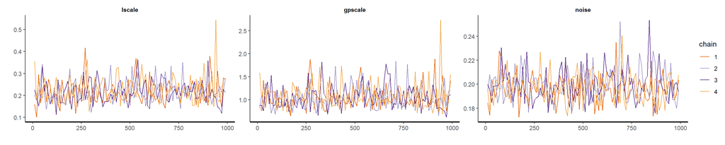

Plot of the posterior distributions

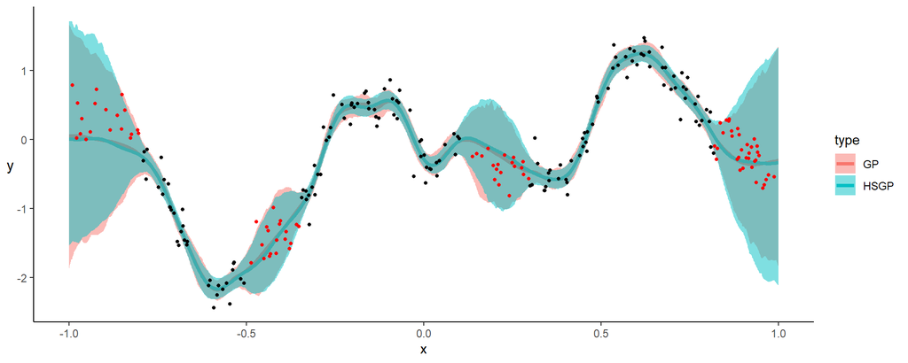

#### Model evaluation

Residuals `residual`, Bayesian $R^2$ (Coefficient of determination), and Log predictive density `lpd`

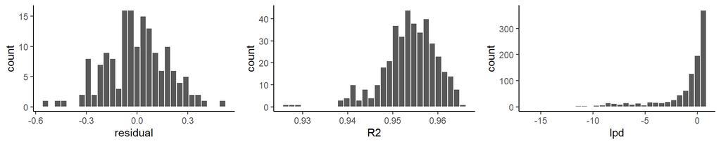

Root mean square error `rmse`, Bayesian $R^2$ (Coefficient of determination), and expected log predictive density `elpd`

| iter | rsme | R2 | elpd |
| --- | --- | --- | --- |
| 1 | 0.257 | 0.917 | -0.112 |
| 2 | 0.182 | 0.955 | -0.013 |
| 3 | 0.182 | 0.954 | -0.029 |

#### Diagnosis

1. Estimated lengthscale $\hat{l_3}$

```
[1] 0.22
```

2. Check the diagnostic of whether $\, \hat{l_3} \geq l_3$

```
[1] TRUE
```

**Summary table**

| iter | GP_func | l | c | m | l_hat | l_hat > l | rmse | R2 | elpd |
| --- | --- | --- | --- | --- | --- | --- | --- | --- | --- |
| 3 | f | 0.12 | 1.5 | 49 | 0.22 | TRUE | 0.182 | 0.954 | -0.029 |

| iter | GP_func | l | c | m | l_hat | l_hat > l | rmse | R2 | elpd |
| --- | --- | --- | --- | --- | --- | --- | --- | --- | --- |
| 1 | f | 0.500 | 2.5 | 18 | 0.132 | FALSE | 0.257 | 0.917 | -0.112 |
| 2 | f | 0.132 | 1.3 | 39 | 0.217 | TRUE | 0.182 | 0.955 | -0.013 |
| 3 | f | 0.120 | 1.5 | 49 | 0.220 | TRUE | 0.182 | 0.954 | -0.029 |